# Assignment3

Zulikah Latief (s4273281)

12/12/2021

```r
#clear list
rm(list=ls())

#set working directory
setwd('C:/Users/user/Documents/MSC AI/MSC AI YEAR 2/Adv stats/R programming/s4273281_assignment3')

#load libraries
library(plyr)
library(plotfunctions)
library(mgcv)    # for GAMs
library(itsadug) # for visualization of GAMs
```

## PART I: Data

```r
#load data
dat <- read.table('data.txt', header= TRUE)
View(dat)

#change rating to familiarity score
dat$Familiarity <- ifelse(dat$Rating > 4, 1, 0)
```

## PART II: Analysis

```r
#center age variable
dat$cAge <- dat$Age - 40
```

**a) Setup a generalized linear model that models the effect of age on idiom familiarity. You can ignore the effect of Condition for this question.**

```r
lm1 <- glm(Familiarity ~ cAge , data=dat, family=binomial)
summary(lm1)
```

```
##
## Call:
## glm(formula = Familiarity ~ cAge, family = binomial, data = dat)
##
## Deviance Residuals:
##     Min       1Q   Median       3Q      Max
## -2.2464  -1.3299   0.6798   0.9443   1.1510
##
## Coefficients:
##              Estimate Std. Error z value Pr(>|z|)
## (Intercept) 0.9619477  0.0127513   75.44   <2e-16 ***
## cAge        0.0321222  0.0008004   40.13   <2e-16 ***
## ---
## Signif. codes:  0 '***' 0.001 '**' 0.01 '*' 0.05 '.' 0.1 ' ' 1
##
## (Dispersion parameter for binomial family taken to be 1)
##
##     Null deviance: 41475  on 34181  degrees of freedom
## Residual deviance: 39674  on 34180  degrees of freedom
## AIC: 39678
##
## Number of Fisher Scoring iterations: 4
```

**b)Setup a generalized additive model that includes exactly the same formula as model lm1 to model the effect of age on idiom familiarity. Compare the two summaries. Describe in your report what the two models predict for the effect of age on the idiom familiarity.**

```r
g1 <- gam(Familiarity ~ cAge, data=dat, family=binomial)
summary(g1)
```

```
##
## Family: binomial
## Link function: logit
##
## Formula:
## Familiarity ~ cAge
##
## Parametric coefficients:
##              Estimate Std. Error z value Pr(>|z|)
## (Intercept) 0.9619477  0.0127513   75.44   <2e-16 ***
## cAge        0.0321222  0.0008004   40.13   <2e-16 ***
## ---
## Signif. codes:  0 '***' 0.001 '**' 0.01 '*' 0.05 '.' 0.1 ' ' 1
##
##
## R-sq.(adj) =  0.0523   Deviance explained = 4.34%
## UBRE = 0.1608  Scale est. = 1         n = 34182
```

```r
summary(lm1)
```

```
##
## Call:
## glm(formula = Familiarity ~ cAge, family = binomial, data = dat)
##
## Deviance Residuals:
##     Min       1Q   Median       3Q      Max
## -2.2464  -1.3299   0.6798   0.9443   1.1510
##
## Coefficients:
##              Estimate Std. Error z value Pr(>|z|)
## (Intercept) 0.9619477  0.0127513   75.44   <2e-16 ***
## cAge        0.0321222  0.0008004   40.13   <2e-16 ***
## ---
## Signif. codes:  0 '***' 0.001 '**' 0.01 '*' 0.05 '.' 0.1 ' ' 1
##
## (Dispersion parameter for binomial family taken to be 1)
##
##     Null deviance: 41475  on 34181  degrees of freedom
## Residual deviance: 39674  on 34180  degrees of freedom
## AIC: 39678
##
## Number of Fisher Scoring iterations: 4
```

Both the models show the main effects of age on familiarity. The intercept represents the mean log odds of familiarity success (familiarity=1) when the age is 40. The positive coefficient of the cAge tells us that the probability of familiarity success increases with age. So for a unit increase in age, the log odds of familiarity success increases by a value of 0.0321222. This is represented in both the models. Moreover, the z-value indicates that the estimates made by the models are significantly different from taking the value zero.

**Setup a generalized additive model that includes a potentially nonlinear effect of age on idiom familiarity.**

```r
g2 <- gam(Familiarity ~ s(cAge) , data=dat, family=binomial)
```

**Inspect the summary of model g2. Explain in your report what the summary tells us about the fitted regression line.**

```r
#summary of model g2
summary(g2)
```

```
##
## Family: binomial
## Link function: logit
##
## Formula:
## Familiarity ~ s(cAge)
##
## Parametric coefficients:
##             Estimate Std. Error z value Pr(>|z|)
## (Intercept)  0.93905    0.01292   72.67   <2e-16 ***
## ---
## Signif. codes:  0 '***' 0.001 '**' 0.01 '*' 0.05 '.' 0.1 ' ' 1
##
## Approximate significance of smooth terms:
##           edf Ref.df Chi.sq p-value
## s(cAge) 8.841  8.987   1790  <2e-16 ***
## ---
## Signif. codes:  0 '***' 0.001 '**' 0.01 '*' 0.05 '.' 0.1 ' ' 1
##
## R-sq.(adj) =  0.0578   Deviance explained = 4.87%
## UBRE = 0.1548  Scale est. = 1         n = 34182
```

```
## Summary:
##  * cAge : numeric predictor; with 30 values ranging from -28.000000 to 46.000000.
##  * NOTE : No random effects in the model to cancel.
##
```

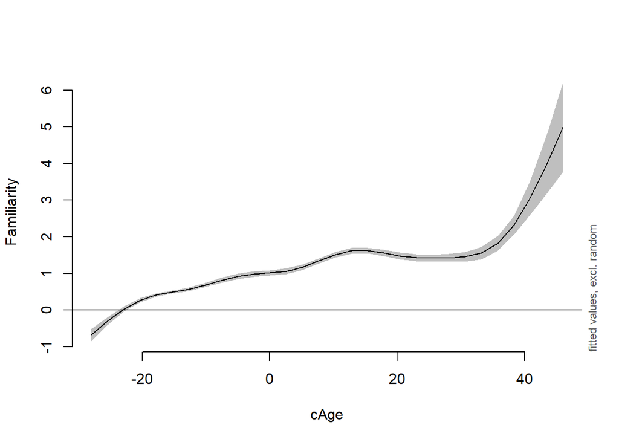

```r
#visualize fitted effects
plot_smooth(g2, view="cAge")
```

The parametric coefficients list the linear variables of the model. Note that for the model g1, the parametric coefficients also included the cAge variable, whereas for the g2 model, since we map the cAge variable with a smooth function, the model includes this as a non-linear effect. The intercept denotes the mean value of familiarity score on a log odds scale at the average age of 40 (cAge is 0). The corresponding z-value indicates that the estimate is significantly different from being zero.

Under the smooth terms we have the non-linear effect of the cAge variable. EDF value of 8 indicates that the effect of cAge is non-linear and we should expect a wiggly curve (as seen in the plot). This edf value is significantly different from 1, which would denote a straight line or a linear relationship. Furthermore, the p-value corresponding to cAge shows that it is a significant predictor. The r-sq is a goodness of fit measure that shows a very low value of 0.0578, which means that the model can only account for ~5 percent of that data.

## Question 2: Visualization

**Explain the difference between the two plots. What is represented by the two plots?**

Plot 1 shows the partial effects of the model. This plot shows the effect of the smooth term cAge on the model prediction (familiarity score). Plot 2 shows the fitted effect, which is the same as the partial effects in this case because we have only one smooth term. The effect of the smooth term (cAge) accounts for the overall prediction of the model. If there was more than one smooth term then the plot corresponding to each of the smooth terms would show the partial effect of that variable on the model prediction. And by summing up all the partial effects, one can get the overall fitted effect of the model.

```
## Summary:
##  * cAge : numeric predictor; with 30 values ranging from -28.000000 to 46.000000.
##  * NOTE : No random effects in the model to cancel.
##
```

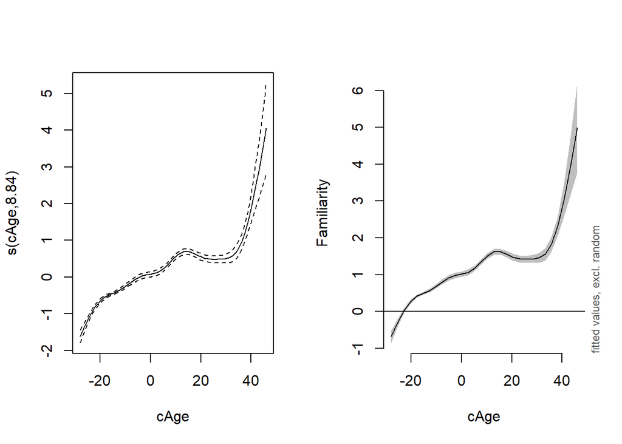

```r
par(mfrow=c(1,2))

# PLOT 1
plot(g2)

# PLOT 2
plot_smooth(g2, view="cAge")
```

**Compare models g2 and g2b by printing the summaries and plotting the regression lines. Explain how centering affects regression lines differently in linear regression models and GAMs. How does this relate to the interpretation of the intercept?**

From the plots, it can be seen that centering does not affect the regression lines in GAMS. The intercept represents the average log odds of familiarity success when age is centered at the mean.

On the other hand, for linear regression models, the intercept represents the avg value of y when x takes on a value of zero. Thus, for linear regression models, the predictors are not centered by default, instead centering is done manually (for example: dat$cAge <- dat$Age - 40). By doing so, the interpretation of the intercept becomes similar to the intercept of the GAM model. Furthermore, the plots become more interpretable.

```r
#using Age instead of cAge
g2b <- gam(Familiarity ~ s(Age) , data=dat, family=binomial)
summary(g2b)
```

```
##
## Family: binomial
## Link function: logit
##
## Formula:
## Familiarity ~ s(Age)
##
## Parametric coefficients:
##             Estimate Std. Error z value Pr(>|z|)
## (Intercept)  0.93905    0.01292   72.67   <2e-16 ***
## ---
## Signif. codes:  0 '***' 0.001 '**' 0.01 '*' 0.05 '.' 0.1 ' ' 1
##
## Approximate significance of smooth terms:
##          edf Ref.df Chi.sq p-value
## s(Age) 8.841  8.987   1790  <2e-16 ***
## ---
## Signif. codes:  0 '***' 0.001 '**' 0.01 '*' 0.05 '.' 0.1 ' ' 1
##
## R-sq.(adj) =  0.0578   Deviance explained = 4.87%
## UBRE = 0.1548  Scale est. = 1         n = 34182
```

```r
summary(g2)
```

```
##
## Family: binomial
## Link function: logit
##
## Formula:
## Familiarity ~ s(cAge)
##
## Parametric coefficients:
##             Estimate Std. Error z value Pr(>|z|)
## (Intercept)  0.93905    0.01292   72.67   <2e-16 ***
## ---
## Signif. codes:  0 '***' 0.001 '**' 0.01 '*' 0.05 '.' 0.1 ' ' 1
##
## Approximate significance of smooth terms:
##           edf Ref.df Chi.sq p-value
## s(cAge) 8.841  8.987   1790  <2e-16 ***
## ---
## Signif. codes:  0 '***' 0.001 '**' 0.01 '*' 0.05 '.' 0.1 ' ' 1
##
## R-sq.(adj) =  0.0578   Deviance explained = 4.87%
## UBRE = 0.1548  Scale est. = 1         n = 34182
```

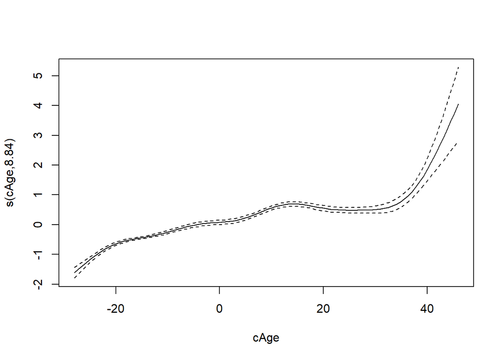

```r
# PLOT 1
plot(g2)
```

```
## Summary:
##  * cAge : numeric predictor; with 30 values ranging from -28.000000 to 46.000000.
##  * NOTE : No random effects in the model to cancel.
##
```

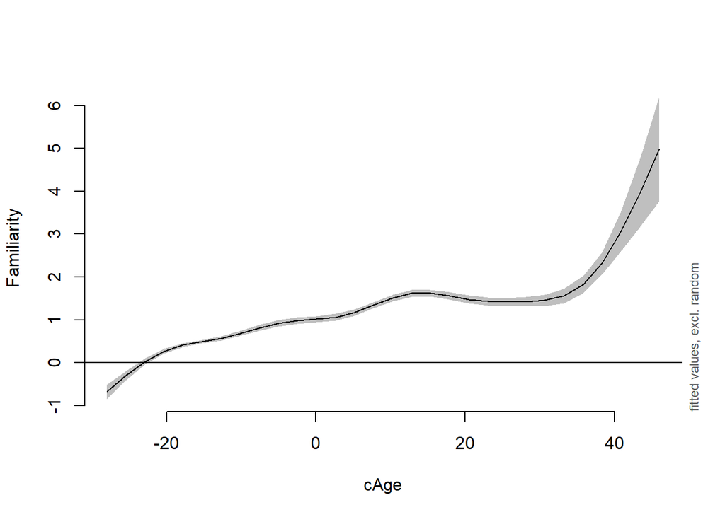

```r
# PLOT 2
plot_smooth(g2, view="cAge")
```

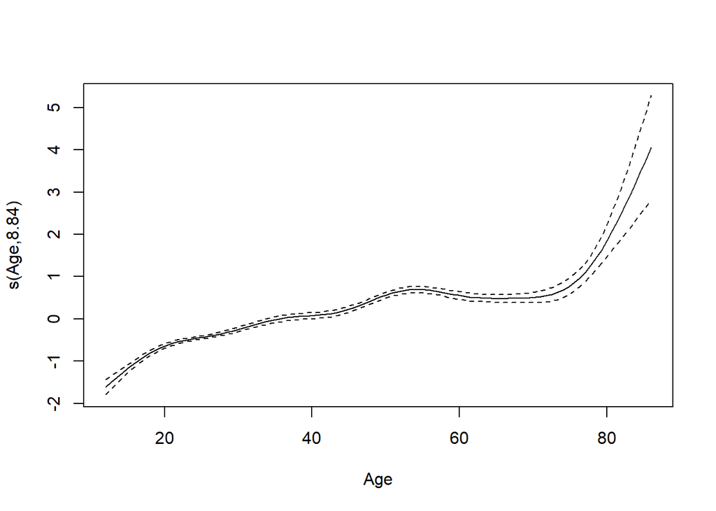

```r
# PLOT 1
plot(g2b)
```

```
## Summary:
##  * Age : numeric predictor; with 30 values ranging from 12.000000 to 86.000000.
##  * NOTE : No random effects in the model to cancel.
##
```

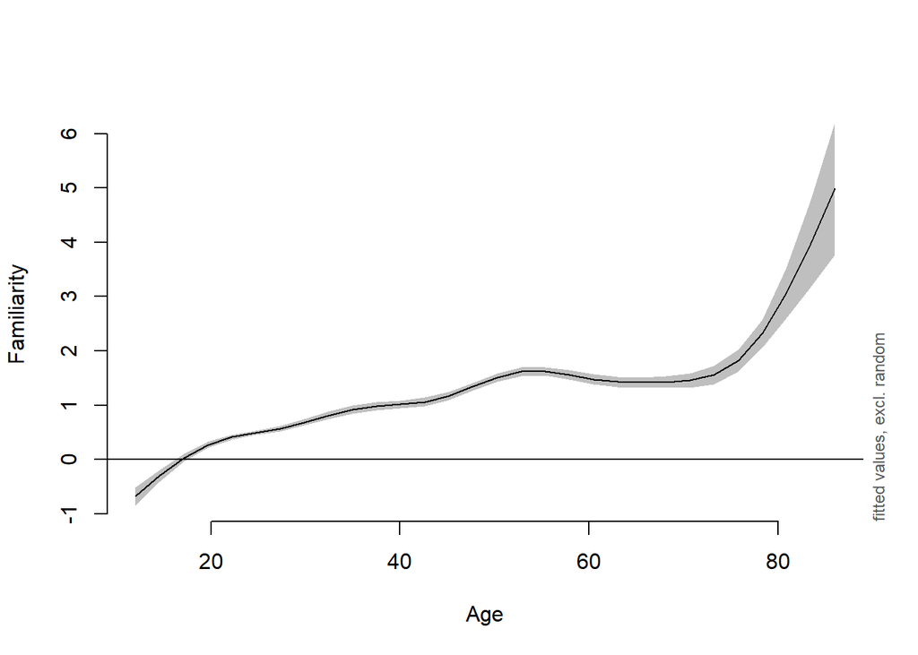

```r
# PLOT 2
plot_smooth(g2b, view="Age")
```

## Question 3: Increasing complexity

**To investigate whether the experimental study (column Condition) influenced the idiom familiarity, extend the GAM model g2b with a main effect of the predictor Condition.**

```r
#convert condition to a factor
dat$Cond <- as.factor(ifelse(dat$Condition=='Study1', "Study1", "Study2"))
levels(dat$Cond)
```

```
## [1] "Study1" "Study2"
```

```r
#extended GAM model with condition as a main effect
g3 <- gam(Familiarity ~ Cond + s(Age) , data=dat, family=binomial)
```

**a)Inspect the summary and visualize the model’s estimates using the code below. Explain what the intercept represents.**

—–The intercept represents the mean familiarity score in log odds for study1 when the age is centered at 0. Thus, it represents the intercept adjustment when the condition is set to study1.—-

```r
#summary of g3
summary(g3)
```

```
##
## Family: binomial
## Link function: logit
##
## Formula:
## Familiarity ~ Cond + s(Age)
##
## Parametric coefficients:
##             Estimate Std. Error z value Pr(>|z|)
## (Intercept)  1.09232    0.01565   69.79   <2e-16 ***
## CondStudy2  -0.56013    0.02962  -18.91   <2e-16 ***
## ---
## Signif. codes:  0 '***' 0.001 '**' 0.01 '*' 0.05 '.' 0.1 ' ' 1
##
## Approximate significance of smooth terms:
##          edf Ref.df Chi.sq p-value
## s(Age) 8.828  8.985   2033  <2e-16 ***
## ---
## Signif. codes:  0 '***' 0.001 '**' 0.01 '*' 0.05 '.' 0.1 ' ' 1
##
## R-sq.(adj) =  0.0679   Deviance explained = 5.73%
## UBRE = 0.14451  Scale est. = 1         n = 34182
```

```
## Summary:
##  * Cond : factor; set to the value(s): Study1, Study2.
##  * Age : numeric predictor; with 30 values ranging from 12.000000 to 86.000000.
##  * NOTE : No random effects in the model to cancel.
##
```

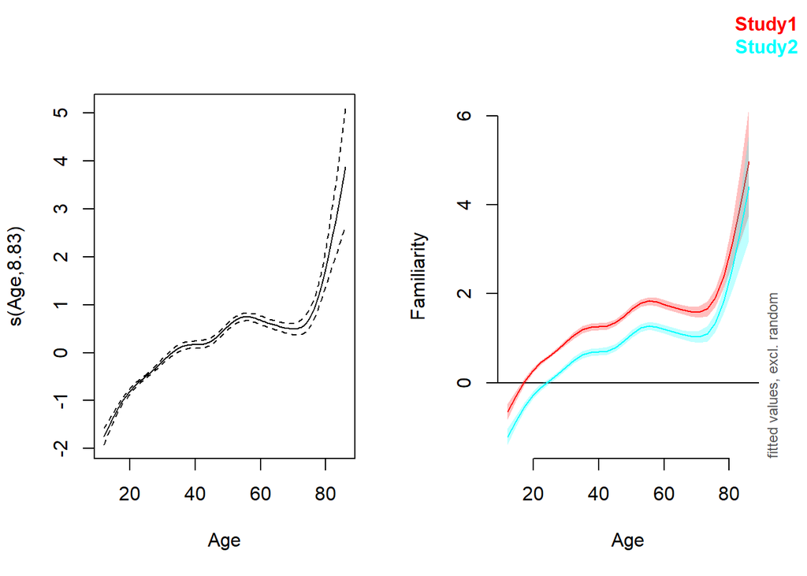

```r
par(mfrow=c(1,2))

# PLOT 1
plot(g3)

# PLOT 2
plot_smooth(g3, view="Age", plot_all="Cond")
```

**b)In this specific case, when we did not include random effects or other features of the GAM model, we could use the function anova to compare whether including Condition improved the modelfit. Discuss your conclusion in your report. Which model is preferred?**

```r
anova(g2b,g3, test="Chisq")
```

```
## Analysis of Deviance Table
##
## Model 1: Familiarity ~ s(Age)
## Model 2: Familiarity ~ Cond + s(Age)
##   Resid. Df Resid. Dev      Df Deviance  Pr(>Chi)
## 1     34172      39454
## 2     34171      39100 0.99794   353.95 < 2.2e-16 ***
## ---
## Signif. codes:  0 '***' 0.001 '**' 0.01 '*' 0.05 '.' 0.1 ' ' 1
```

A chi-square test is performed to examine whether including Condition improves the model fit. The test shows a significant difference between the models, X2 (0.99794) = 353.95, p < 2.2e-16. It can be seen that by spending one additional degree of freedom, the deviance drops significantly. This means that our model 2 with ‘condition’ variable as a main effect fits the data better than model 1. Thus model 2 (g3) is preferred.

**c)Include the (potentially nonlinear) interaction between Condition and age. Inspect the summary and visualize the regression lines (see the code provided for model g3). Explain what the intercept represents.**

The intercept represents the increase in the mean familiarity score for study1 when the age is centered at 0. The negative estimate for CondStudy2 represents the decrease in mean familiarity score by 0.45817 (in the log scale) from study1 to study2.

```r
g4 <- gam(Familiarity ~ Cond + s(Age, by = Cond) , data=dat, family=binomial)
summary(g4)
```

```
##
## Family: binomial
## Link function: logit
##
## Formula:
## Familiarity ~ Cond + s(Age, by = Cond)
##
## Parametric coefficients:
##             Estimate Std. Error z value Pr(>|z|)
## (Intercept)  1.09109    0.01580  69.054  < 2e-16 ***
## CondStudy2  -0.45817    0.07215  -6.351 2.14e-10 ***
## ---
## Signif. codes:  0 '***' 0.001 '**' 0.01 '*' 0.05 '.' 0.1 ' ' 1
##
## Approximate significance of smooth terms:
##                     edf Ref.df Chi.sq p-value
## s(Age):CondStudy1 8.145  8.752 1716.4  <2e-16 ***
## s(Age):CondStudy2 8.963  8.999  598.1  <2e-16 ***
## ---
## Signif. codes:  0 '***' 0.001 '**' 0.01 '*' 0.05 '.' 0.1 ' ' 1
##
## R-sq.(adj) =  0.077   Deviance explained =  6.6%
## UBRE = 0.13444  Scale est. = 1         n = 34182
```

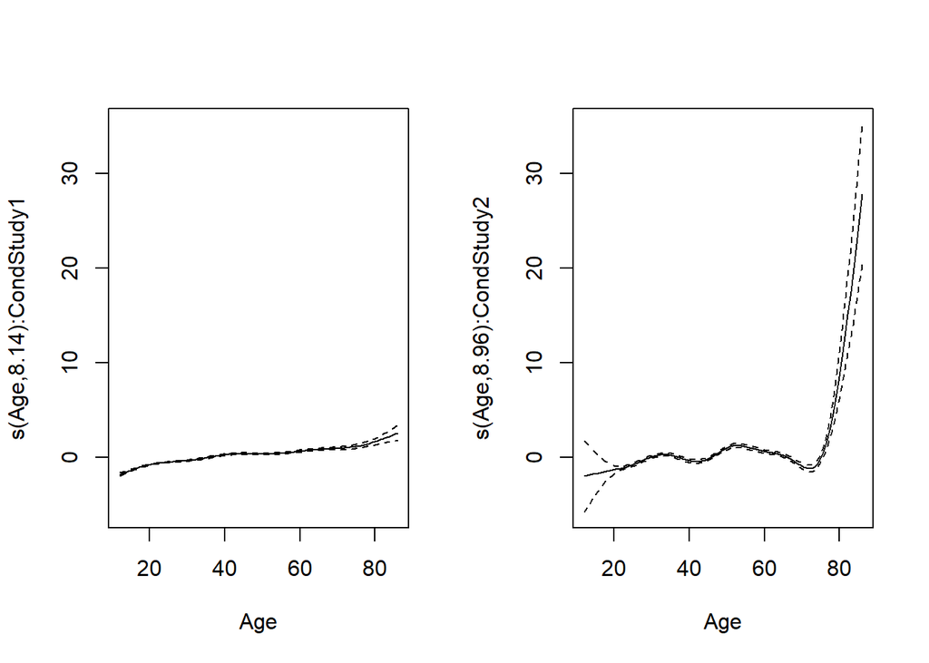

```r
par(mfrow=c(1,2))

# PLOT 1
plot(g4)
```

```
## Summary:
##  * Cond : factor; set to the value(s): Study1, Study2.
##  * Age : numeric predictor; with 30 values ranging from 12.000000 to 86.000000.
##  * NOTE : No random effects in the model to cancel.
##
```

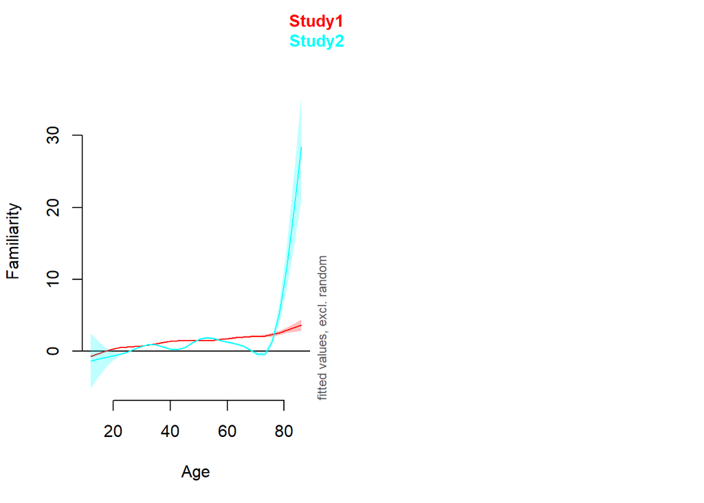

```r
# PLOT 2
plot_smooth(g4, view="Age", plot_all="Cond")
```

**Discuss what you can conclude from the summary with respect to the effects of Condition and Age and their interaction on the idiom familiarity.**

The parametric coefficients represent the adjustments in the intercept for study1 (intercept) and study2 in comparison to study1 (CondStudy2). The smooth terms derived by the interaction between age and condition shows that both terms differ significantly from 0.

**d)Again use anova to test whether the interaction is significantly contributing. What is your conclusion?**

A chi-square test is performed to examine whether including the interaction between Condition and age improves the model fit. The test shows a significant difference between the models, X2 (8.7662) = 360.69, p < 2.2e-16. It can be seen that by spending 9 additional degree of freedom, the deviance drops significantly. This means that our model 2 with the interaction term fits the data better than model 1. Thus model 2 (g4) is preferred.

```r
anova(g3,g4, test="Chisq")
```

```
## Analysis of Deviance Table
##
## Model 1: Familiarity ~ Cond + s(Age)
## Model 2: Familiarity ~ Cond + s(Age, by = Cond)
##   Resid. Df Resid. Dev     Df Deviance  Pr(>Chi)
## 1     34171      39100
## 2     34162      38739 8.7662   360.69 < 2.2e-16 ***
## ---
## Signif. codes:  0 '***' 0.001 '**' 0.01 '*' 0.05 '.' 0.1 ' ' 1
```

## Question 4: Continuous predictors

```r
dat$logFrequency <- log(dat$Frequency+.1)
# May take somewhat more time to run:
g5 <- gam(Familiarity ~ Cond + te(Age, logFrequency, by=Cond),
          data=dat, family=binomial)

par(mfrow=c(1,2), mar=c(5.1,4.1,3.1,4.1))

# PLOT 1
pvisgam(g5, select=1, view=c("Age", "logFrequency"),
        dec=1, zlim=c(-7,3),
        main="Study 1")
```

```
## [1] "Tensor(s) to be plotted: te(Age,logFrequency):CondStudy1"
```

```r
pvisgam(g5, select=2, view=c("Age", "logFrequency"),
        dec=1, zlim=c(-7,3),
        main="Study 2")
```

```
## [1] "Tensor(s) to be plotted: te(Age,logFrequency):CondStudy2"
```

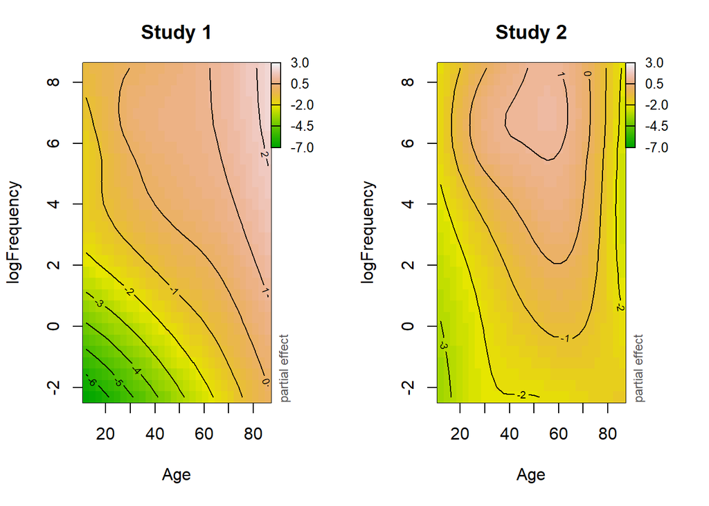

```r
par(mfrow=c(1,2), mar=c(5.1,4.1,3.1,4.1))

range(dat$Age[dat$Condition=='Study2'])
```

```
## [1] 19 76
```

```r
# PLOT 2
fvisgam(g5, view=c("Age", "logFrequency"),
        cond=list(Cond="Study1"),
        dec=1, zlim=c(-6,4),
        main="Study 1")
```

```
## Summary:
##  * Cond : factor; set to the value(s): Study1.
##  * Age : numeric predictor; with 30 values ranging from 12.000000 to 86.000000.
##  * logFrequency : numeric predictor; with 30 values ranging from -2.302585 to 8.452783.
##  * NOTE : No random effects in the model to cancel.
##
```

```
## Summary:
##  * Cond : factor; set to the value(s): Study2.
##  * Age : numeric predictor; with 30 values ranging from 12.000000 to 86.000000.
##  * logFrequency : numeric predictor; with 30 values ranging from -2.302585 to 8.452783.
##  * NOTE : No random effects in the model to cancel.
##
```

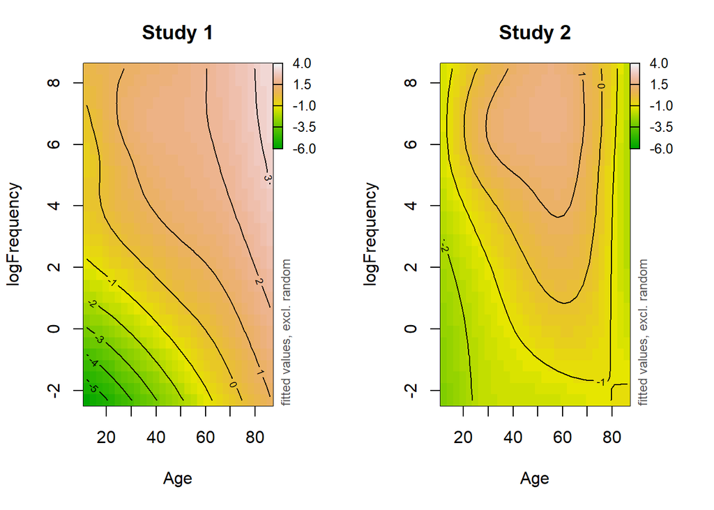

```r
# PLOT 2
fvisgam(g5, view=c("Age", "logFrequency"),
        cond=list(Cond="Study2"),
        dec=1, zlim=c(-6,4),
        main="Study 2")
```

**a)What is the difference between the plots generated with pvisgam and those generated with fvisgam? Interpret the plots and explain in words how the logFrequency and Age influence idiom familiarity.**

pvisgam() plots the partial effects whereas the fvisgam() plots the summed effects. Therefore, fvisgam() gives the additive effect of the smooth terms.

For study1, as logFrequency increases, the log odds of familiarity success increases with age. Moreover, the slope is steeper for for lower logFrequency values and age. The slope becomes less steep as the age and frequency increases.

For study2, the slope more gentle than for study1. It can be seen that, the log odds of the familiarity success increases with the logFrequency and age upto a certain point. Beyond the age of 75, the log odds of the familiarity score reduce even with increased logFrequency values. This can be due to the fact that for study2 the age of all participants falls under 76. Moreover, the effect of age and logfrequency is more non-linear for study2 in comparison to study1. There is a cluster around the age of 40-65 with logFrequency ranging from 6-8, where the log odds of familiarity success are at their highest.

**b)Instead of the function te() we could have use the function ti() for modeling the interaction surface. Provide the formula of a model that captures the same interaction between Age, logFrequency and Condition, as in model g5, but instead uses ti() rather than te().**

```r
g6 <- gam(Familiarity ~ Cond + s(Age) + s(logFrequency) + ti(Age, logFrequency, by=Cond), data=dat, family=binomial)
```